# Predicting ICU Portality in Adults Using MIMIC-IV Data

### 8.3 **XGBoost:**

Prepare the data… Ensure all features are numeric.

```r
# Convert categorical variables to numeric using one-hot encoding
dummies <- dummyVars(mortality ~ ., data = data)
data_one_hot <- predict(dummies, newdata = data)
# Combine the one-hot encoded features with the target variable
data_final <- as.data.frame(data_one_hot)
data_final$mortality <- as.numeric(data$mortality) - 1  # Convert target to 0/1

# Split the data into training and testing sets
set.seed(123)
train_index <- createDataPartition(data_final$mortality, p = 0.7, list = FALSE)
train_data <- data_final[train_index, ]
test_data <- data_final[-train_index, ]

# Prepare data matrices for XGBoost
dtrain <- xgb.DMatrix(data = as.matrix(train_data[, -ncol(train_data)]), label = train_data$mortality)
dtest <- xgb.DMatrix(data = as.matrix(test_data[, -ncol(test_data)]), label = test_data$mortality)
```

```r
# Set XGBoost parameters
params <- list(
  booster = "gbtree",
  objective = "binary:logistic",  # Binary classification
  eval_metric = "auc",           # Use AUC as the evaluation metric
  eta = 0.1,                     # Learning rate
  max_depth = 6,                 # Maximum tree depth
  min_child_weight = 1,          # Minimum sum of instance weight
  subsample = 0.8,               # Fraction of data for training
  colsample_bytree = 0.8         # Fraction of features per tree
)

# Train the XGBoost model
xgb_model <- xgb.train(
  params = params,
  data = dtrain,
  nrounds = 100,                 # Number of boosting rounds
  watchlist = list(train = dtrain, eval = dtest),  # Monitor performance
  early_stopping_rounds = 10,    # Stop if no improvement after 10 rounds
  print_every_n = 10             # Print progress every 10 rounds
)
```

```
Multiple eval metrics are present. Will use eval_auc for early stopping.
Will train until eval_auc hasn't improved in 10 rounds.
```

```r
# Predict probabilities on the test set
xgb_probs <- predict(xgb_model, newdata = dtest)

# Convert probabilities to binary predictions
xgb_predictions <- ifelse(xgb_probs > 0.5, 1, 0)

# Confusion matrix
confusion_matrix <- table(test_data$mortality, xgb_predictions)
print("Confusion Matrix:")
```

```
[1] "Confusion Matrix:"
```

```r
print(confusion_matrix)
```

```
   xgb_predictions
       0    1
  0 5342 1508
  1 1132 5555
```

```r
# Calculate AUC
roc_curve <- roc(test_data$mortality, xgb_probs)
auc_score <- auc(roc_curve)
print(paste("AUC:", round(auc_score, 4)))
```

```
[1] "AUC: 0.8912"
```

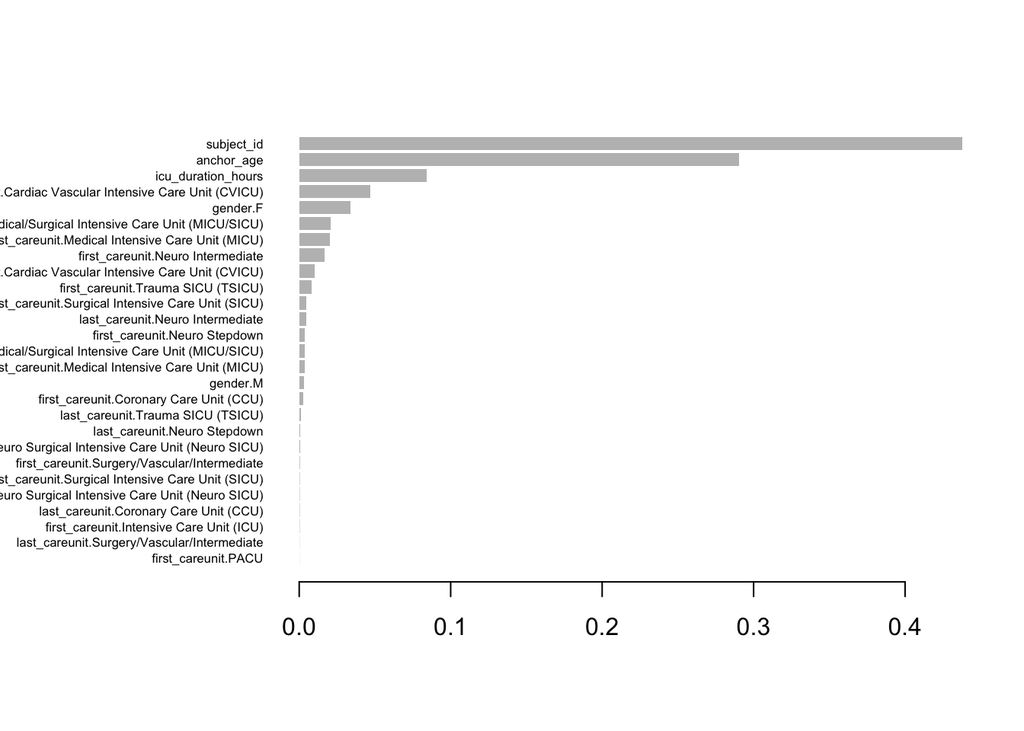

```r
# Get and plot feature importance
importance_matrix <- xgb.importance(feature_names = colnames(train_data[, -ncol(train_data)]), model = xgb_model)
xgb.plot.importance(importance_matrix)
```

- XGBoost’s results demonstrate that it effectively models the relationship between features and mortality outcomes - but it does not outperform Random Forest for this specific dataset.
  - XGBoost includes mechanisms like regularization (L1 and L2) and early stopping, which helps to prevent overfitting and enhances model generalization. Its flexibility and regularization features make it a powerful choice for predictive modeling… While XGBoost is typically robust, its performance here might have been impacted by feeature encoding (one-hot encoding may have introduced sparsity, affecting performance) or model hyperparameters (fine-tuning, like adjusting learning rate, max depth, or boosting rounds could potentially improve performance).